# Introduction to CART

Classification And Regression Tree approach (CART) can be used in both classification (nominal type of outcome variable) and regression tasks (numeric outcome). Several algorithms were designed for identification of the three (split rules and model’s complexity). CART is also a name of an old algorithm which is copyright-protected. In R `rpart` (Recursive Partitioning and Regression Trees) name is used instead.

In this document library `rpart` will be demonstrated in connection with `rattle` package which contains nice visualisation dunction `fancyRpartPlot`.

```r
suppressPackageStartupMessages( library(dplyr) )
library(rpart) #install.packages("rpart")
suppressMessages( library(rattle) )#install.packages("rattle")
library(datasets) # install.packages("datasets")
```

We will demonstrate `rpart` abilities on a toy example from `mtcars`

```r
data(mtcars)
head(mtcars)
```

```
##                    mpg cyl disp  hp drat    wt  qsec vs am gear carb
## Mazda RX4         21.0   6  160 110 3.90 2.620 16.46  0  1    4    4
## Mazda RX4 Wag     21.0   6  160 110 3.90 2.875 17.02  0  1    4    4
## Datsun 710        22.8   4  108  93 3.85 2.320 18.61  1  1    4    1
## Hornet 4 Drive    21.4   6  258 110 3.08 3.215 19.44  1  0    3    1
## Hornet Sportabout 18.7   8  360 175 3.15 3.440 17.02  0  0    3    2
## Valiant           18.1   6  225 105 2.76 3.460 20.22  1  0    3    1
```

```r
str(mtcars)
```

```
## 'data.frame':    32 obs. of  11 variables:
##  $ mpg : num  21 21 22.8 21.4 18.7 18.1 14.3 24.4 22.8 19.2 ...
##  $ cyl : num  6 6 4 6 8 6 8 4 4 6 ...
##  $ disp: num  160 160 108 258 360 ...
##  $ hp  : num  110 110 93 110 175 105 245 62 95 123 ...
##  $ drat: num  3.9 3.9 3.85 3.08 3.15 2.76 3.21 3.69 3.92 3.92 ...
##  $ wt  : num  2.62 2.88 2.32 3.21 3.44 ...
##  $ qsec: num  16.5 17 18.6 19.4 17 ...
##  $ vs  : num  0 0 1 1 0 1 0 1 1 1 ...
##  $ am  : num  1 1 1 0 0 0 0 0 0 0 ...
##  $ gear: num  4 4 4 3 3 3 3 4 4 4 ...
##  $ carb: num  4 4 1 1 2 1 4 2 2 4 ...
```

All variables are numerical. New variable *heavy_car* will be created by following rule:

```r
mtcars$heavy_car <- ifelse(mtcars$wt > 3, "heavy", "light")
table(mtcars$heavy_car)
```

```
##
## heavy light
##    20    12
```

```r
prop.table(table(mtcars$heavy_car) )
```

```
##
## heavy light
## 0.625 0.375
```

## Classification

Now, the task would be to estimate whether particular car is heavy or not given the set of covariates *hp, qsec* (horse power and 1/4 mile time). Model is created as:

```r
fit.c <- rpart(heavy_car ~ hp + qsec, data = mtcars)
```

Elementary visualisation can be done directly from the `plot` function. To create nicer plot, `rattle::fancyRpartPlot` will be used instead.

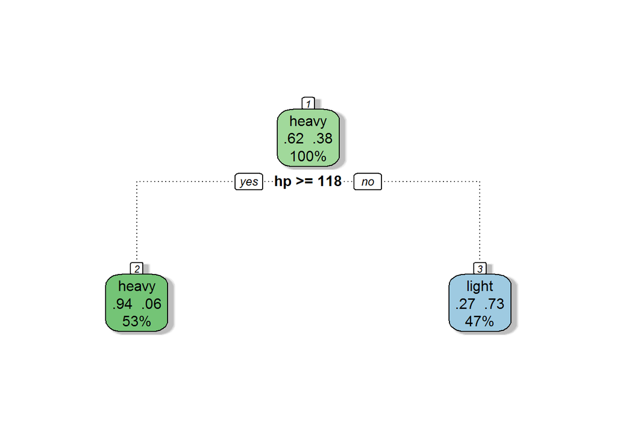

```r
fancyRpartPlot(fit.c, sub="") # sub parameter removes subtitle
```

The best way how to decide about the class is to use variable *hp*. In the top of the tree green node is showed. Word *heavy* represents majority group in this level of decison. Colour represents the class. Two numbers below correspond to proportions of classes. Check the proportion discussed above. If the car’s horse power exceeds value 118, car is assigned as a heavy car.

```r
fit.c
```

```
## n= 32
##
## node), split, n, loss, yval, (yprob)
##       * denotes terminal node
##
## 1) root 32 12 heavy (0.62500000 0.37500000)
##   2) hp>=118 17  1 heavy (0.94117647 0.05882353) *
##   3) hp< 118 15  4 light (0.26666667 0.73333333) *
```

Now, after the model is learned, it’s possible to classify all cars according to rules created in the `fit.c` model. Following outcome shows probability of being in the group denoted in the column name.

```r
predict(fit.c) %>% head(5)
```

```
##                       heavy      light
## Mazda RX4         0.2666667 0.73333333
## Mazda RX4 Wag     0.2666667 0.73333333
## Datsun 710        0.2666667 0.73333333
## Hornet 4 Drive    0.2666667 0.73333333
## Hornet Sportabout 0.9411765 0.05882353
```

If you prefer direct label, you just change parameter in the `predict` function:

```r
predict(fit.c, type="class") %>% head(5)
```

```
##         Mazda RX4     Mazda RX4 Wag        Datsun 710    Hornet 4 Drive
##             light             light             light             light
## Hornet Sportabout
##             heavy
## Levels: heavy light
```

## Regression

Now we will try to estimate the fuel consumption given the covariates *hp, qsec, wt*.

```r
fit.r <- rpart(mpg ~ hp + qsec + wt, data = mtcars)
```

Inspect the model in textual form:

```r
fit.r
```

```
## n= 32
##
## node), split, n, deviance, yval
##       * denotes terminal node
##
## 1) root 32 1126.04700 20.09062
##   2) wt>=2.3925 25  320.44640 17.58800
##     4) hp>=177.5 10   48.53600 14.28000 *
##     5) hp< 177.5 15   89.52933 19.79333 *
##   3) wt< 2.3925 7   89.81429 29.02857 *
```

and in a visual form:

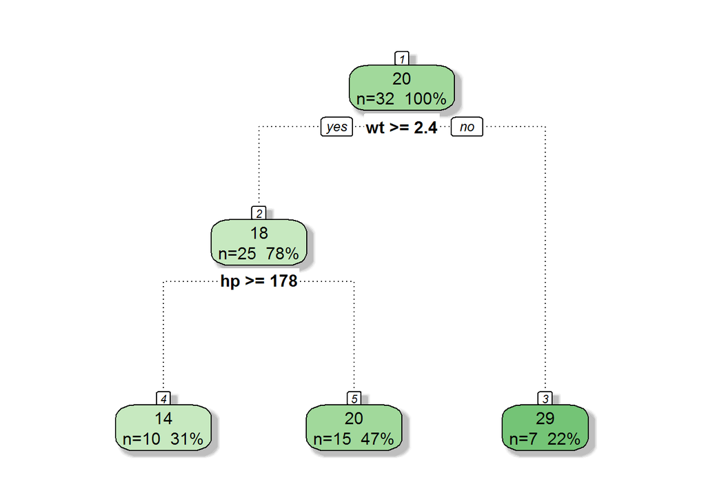

```r
fancyRpartPlot(fit.r, sub="")
```

Finally, make a prediction of the fuel consumption (*mpg*):

```r
predict(fit.r) %>% head(5)
```

```
##         Mazda RX4     Mazda RX4 Wag        Datsun 710    Hornet 4 Drive
##          19.79333          19.79333          29.02857          19.79333
## Hornet Sportabout
##          19.79333
```

Check the correctness:

```r
results <- data.frame(mpg.real=mtcars$mpg, mpg.predicted = predict(fit.r))

results %>% head(5)
```

```
##                   mpg.real mpg.predicted
## Mazda RX4             21.0      19.79333
## Mazda RX4 Wag         21.0      19.79333
## Datsun 710            22.8      29.02857
## Hornet 4 Drive        21.4      19.79333
## Hornet Sportabout     18.7      19.79333
```

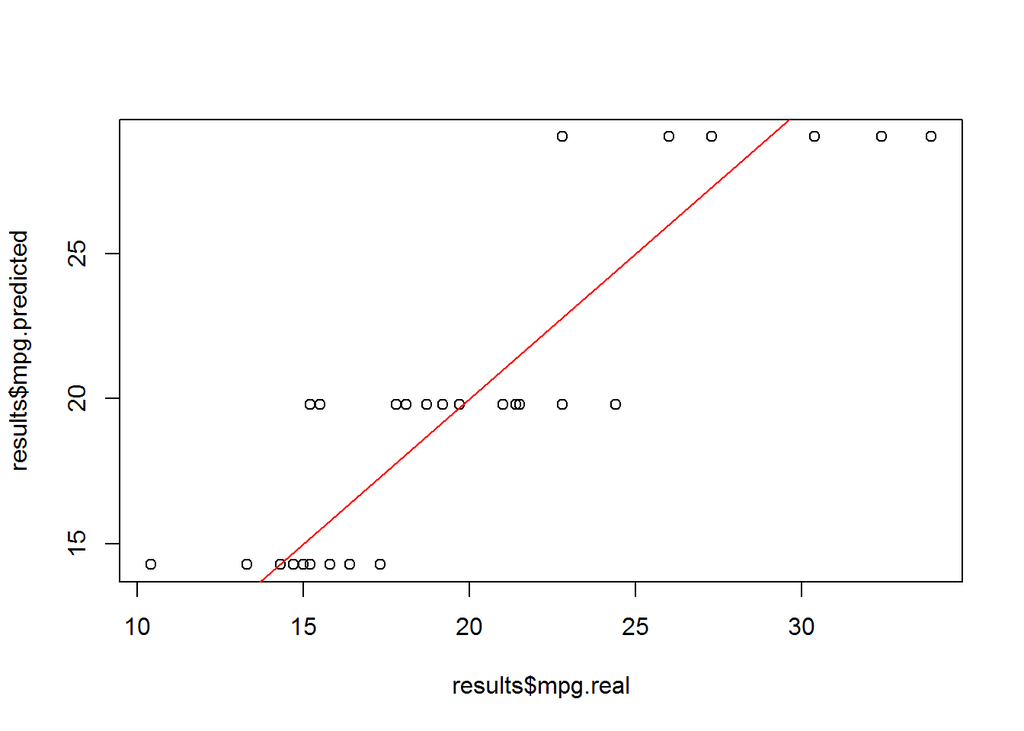

```r
plot(results$mpg.predicted ~ results$mpg.real)
abline(a=0, b=1, col="red")
```

If the points would lie on the line, predicted values would be the same as real.